# M08 - Artrite Idiopática Juvenil (AIJ)

Pietro Garmatter

2024-09-17

```r
library(fpp3)
library(tidyverse)
library(RPostgres)
library(DBI)
library(GGally)
library(ggdist)
library(ggfortify)
library(MASS)
library(splines)
library(patchwork)
library(distributional)

setwd("E:/GEATS/Estimador-AIO-SUS/M08/")
load("M08.RData")

select <- dplyr::select
```

# Exploratória Soma

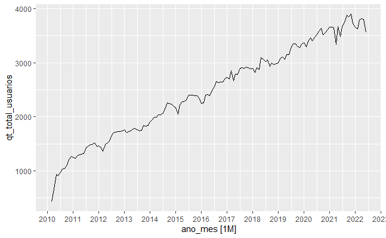

```r
autoplot(soma, qt_total_usuarios) +
  scale_x_yearmonth(date_breaks = '1 year', date_labels='%Y')
```

```r
mean(soma$qt_total_usuarios)
var(soma$qt_total_usuarios)
```

Apesar de bastantes observações, média e variância diferentes. É possível fazer análises, mas não utilizar Poisson no GLM (superdispersão).

```r
gg_tsdisplay(soma, y = qt_total_usuarios, plot_type = "partial")
```

[output not shown]

FAC e FACP sugerem processo AR(1). Série diferenciada bastante estacionária, certa variância maior perto do final.

```r
(lb12 = format(ljung_box(soma$qt_total_usuarios, lag = 12)["lb_pvalue"], nsmall = 4))
```

```
lb_pvalue
 "0.0000"
```

```r
(lb24 = format(ljung_box(soma$qt_total_usuarios, lag = 24)["lb_pvalue"], nsmall = 4))
```

```
lb_pvalue
 "0.0000"
```

Os testes de Ljung-Box para 12 e 24 meses rejeita a hipótese nula de que a série seja ruído branco com valores de p iguais a 0.0000 e 0.0000.

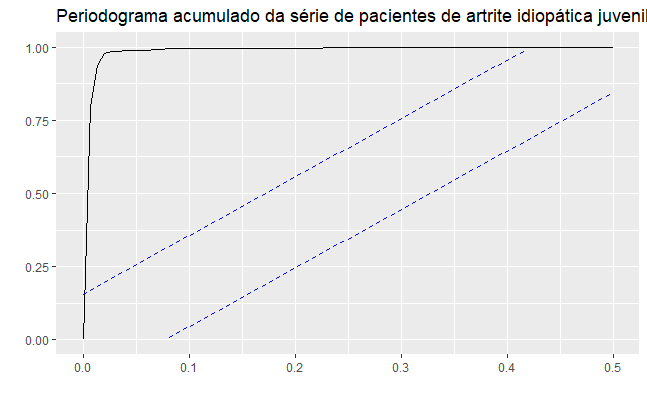

```r
ggcpgram(soma$qt_total_usuarios) +
  labs(title = 'Periodograma acumulado da série de pacientes de artrite idiopática juvenil.')
```

Tudo indica que a soma pode ser modelada.

# Modelagem Soma

Modelo proposto ARIMA(110) com drift e sem sazonalidade.

```r
soma.treino <- soma %>% filter(ano_mes < yearmonth("2020/06"))

models <- soma.treino %>%
  model(A = ARIMA(qt_total_usuarios ~ 1 + pdq(1,1,0) + PDQ(0,0,0)),
        B = ARIMA(qt_total_usuarios),
        C = ETS(qt_total_usuarios ~ error("A") + trend("A") + season("N")),
        D = ETS(qt_total_usuarios ~ error("M") + trend("A") + season("N")),
        E = TSLM(qt_total_usuarios ~ ano_mes))

quasipoisson = glm(qt_total_usuarios ~ ano_mes, soma.treino, family = quasipoisson())

binomialneg = glm.nb(qt_total_usuarios ~ ano_mes, soma.treino)
nb.label = "F"

glance(models) %>%
  select(.model, AIC) %>%
  bind_rows(data.frame(.model = c('quasipoisson', nb.label), AIC = c(NA, AIC(binomialneg))))
```

| .model | AIC |
| --- | --- |
| A | 1380.215 |
| B | 1377.174 |
| C | 1642.775 |
| D | 1685.917 |
| E | 1135.677 |
| quasipoisson | NA |
| F | 1705.390 |

Modelo E (TSLM) teve o melhor AIC seguido de B (ARIMA(0,1,0)(1,0,0)[12] w/ drift encontrado com stepwise) e A (ARIMA proposto).

# Análise de resíduos (soma)

```r
mean(soma$qt_total_usuarios)
```

```
[1] 2467.527
```

```r
var(soma$qt_total_usuarios)
```

```
[1] 728189.4
```

O modelo E teve um bom ajuste da média, com os menores resíduos registrados (REQM 148.5165), enquanto não teve um bom desempenho quanto ao intervalo preditivo (escore 1128.0271). No geral, o modelo C (suavização exponencial de Holt) teve um bom REQM (161.8803) e o melhor escore (778.8805).

# Análise dos gráficos Soma

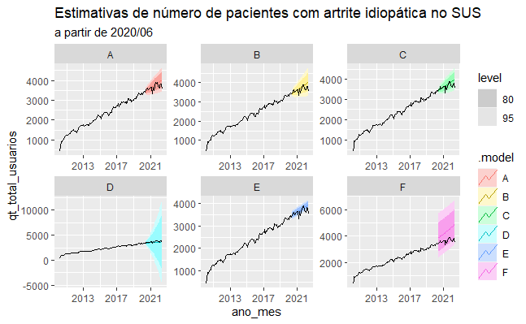

```r
cast %>%
  autoplot(soma) +
  facet_wrap(~ .model, scales = "free") +
  scale_x_yearmonth(date_breaks = '4 years', date_labels='%Y') +
  labs(title = "Estimativas de número de pacientes com artrite idiopática no SUS",
       subtitle = "a partir de 2020/06")
```

Tanto o modelo C quanto os ARIMAs (A e B) tiveram um comportamento utilizável na predição do número de pacientes totais de artrite idiopática juvenil no SUS. Preferencialmente, o modelo C.